# White Wine Analysis by David DeSimone

# Univariate Analysis

### What is the structure of your dataset?

There are 4,898 white wines in this dataset. There are 12 variables (fixed acidity, volatile acidity, citric acid, residual sugar, chlorides, free sulfur dioxide, total sulfur dioxide, density, pH, sulphates, alcohol, and quality). Most of the variables follow a normal distribution pattern (aside form alcohol), and the numbers in the data are self explainatory.

Some interesting thigs to note:

- There were no ratings lower than a 3, and no perfect 10’s. 9’s were also rare, with a count of 5.
- The distribution of alcohol content is noticably flatter than the rest of the variables and is skewed to the right.

### What is/are the main feature(s) of interest in your dataset?

The main feature of the dataset is quality. I am mostly interested how the other variables directly affect perceived quality or interact with each other to affect perceived quality.

### What other features in the dataset do you think will help support your investigation into your feature(s) of interest?

I might also pay special attention to certain variables which are also easy for an observer to pick up on – things like sugar and alcohol content. Of course, this is only an assumption, and I may find out that, while interesting, they have no effect on quality. Also, I may be surprised to find that variables that observers are oblivious to are affecting perceived quality.

### Did you create any new variables from existing variables in the dataset?

I created buckets for both sugar and alcohol. These will be used in later analysis.

### Of the features you investigated, were there any unusual distributions? Did you perform any operations on the data to tidy, adjust, or change the form of data? If so, why did you do this?

I did log transform the alcohol and sugar variables to better represent their longer right tail. I also cut out big outliers on a couple of the variables in order to get a better look at the bulk of the data for the given variable.

# Bivariate Plots Section

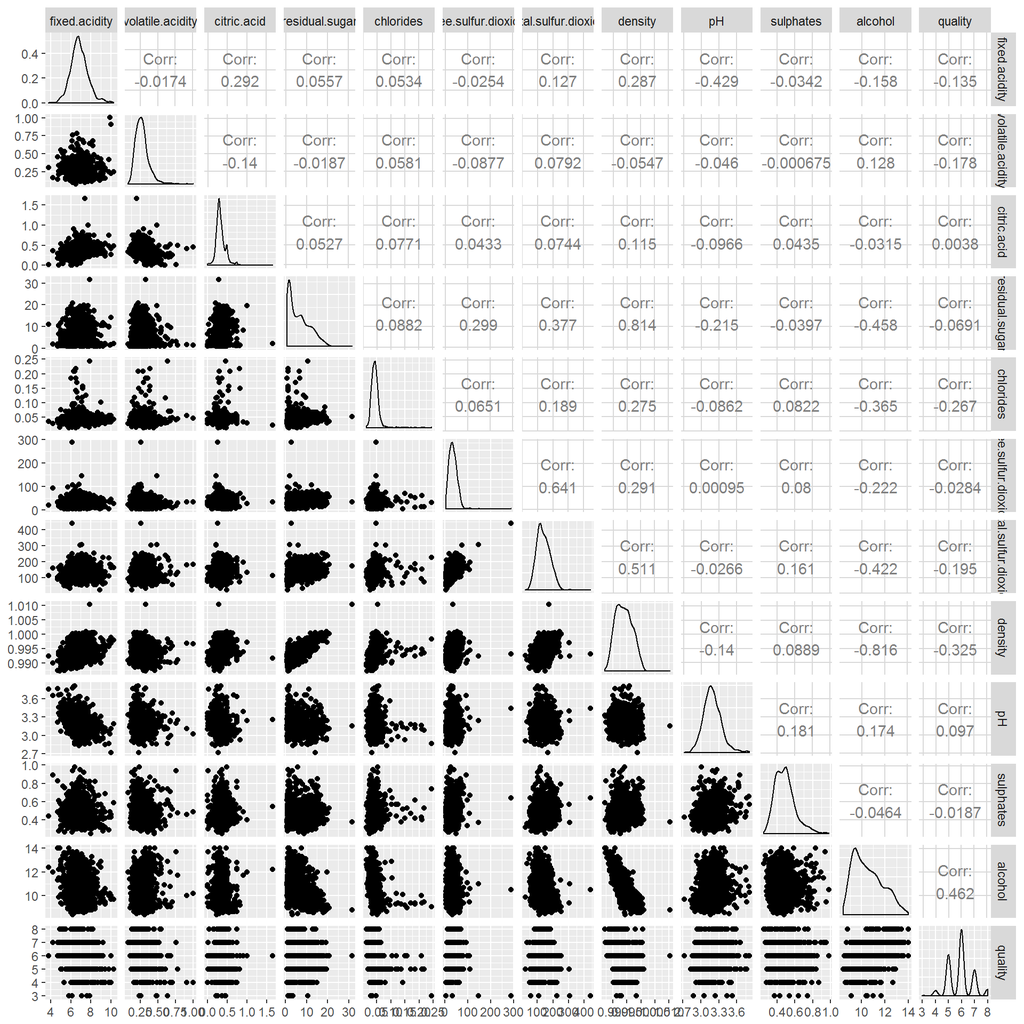

Something else to pay attention to would be residual sugar’s and alcohol’s interatctions with the other variables. There are some decent correlations, and residual sugar and alcohol are both variables that most people can probably taste immediately.

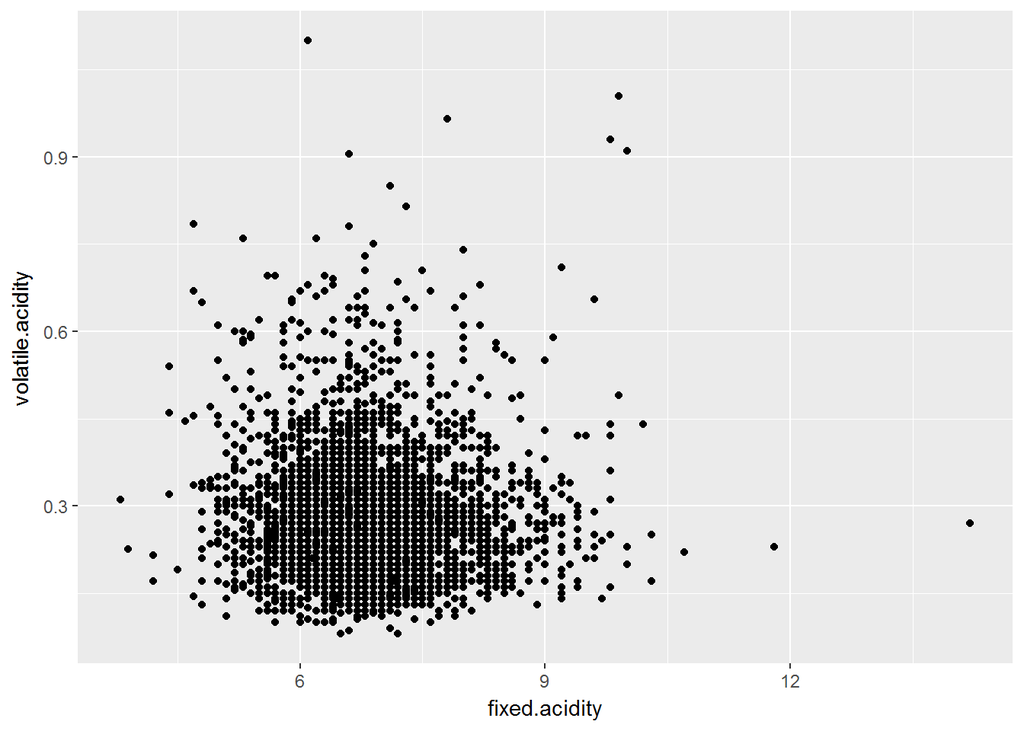

```
##
##  Pearson's product-moment correlation
##
## data:  wine$fixed.acidity and wine$volatile.acidity
## t = -1.5886, df = 4896, p-value = 0.1122
## alternative hypothesis: true correlation is not equal to 0
## 95 percent confidence interval:
##  -0.050671536  0.005312543
## sample estimates:
##         cor
## -0.02269729
```

One of the first things that came to mind when looking at the data was the possible relationship between fixed acidity and volatile acidity, and the relationship between free sulfur dioxide and total sulfur dioxide. I thought that there could be a chance they are correlated and this might reduce the amount of work necessary in the future. While there is no strong correlation between fixed and volatile acidity, free sulfur dioxide and total sulfur dioxide are related to each other with a .62 correlation.

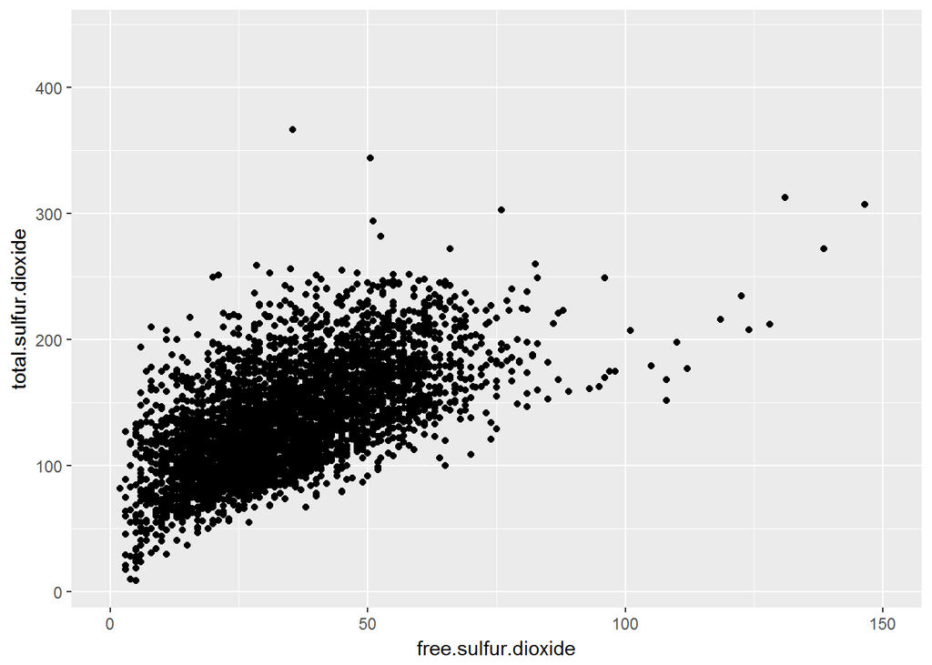

```
##
##  Pearson's product-moment correlation
##
## data:  wine$free.sulfur.dioxide and wine$total.sulfur.dioxide
## t = 54.645, df = 4896, p-value < 2.2e-16
## alternative hypothesis: true correlation is not equal to 0
## 95 percent confidence interval:
##  0.5977994 0.6326026
## sample estimates:
##      cor
## 0.615501
```

Both measures of sulfur have little effect on quality, so I probably won’t be spending much time looking at these variables.

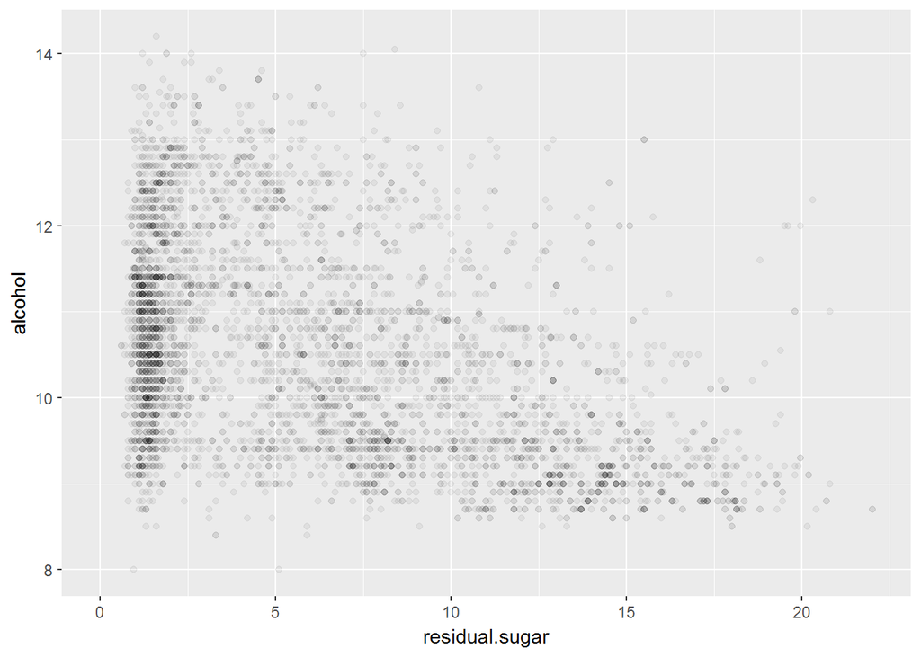

```
##
##  Pearson's product-moment correlation
##
## data:  wine$residual.sugar and wine$alcohol
## t = -35.321, df = 4896, p-value < 2.2e-16
## alternative hypothesis: true correlation is not equal to 0
## 95 percent confidence interval:
##  -0.4726723 -0.4280267
## sample estimates:
##        cor
## -0.4506312
```

Here we can see for wines with sugar content less than 5, the entire range of alcohol is found. As sugar content becomes higher, alcohol content seems to decrease.

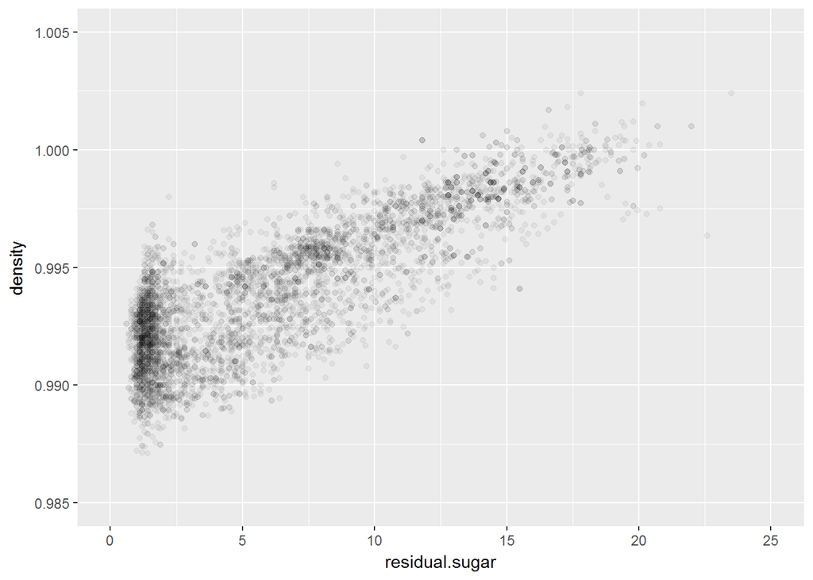

```
##
##  Pearson's product-moment correlation
##
## data:  wine$residual.sugar and wine$density
## t = 107.87, df = 4896, p-value < 2.2e-16
## alternative hypothesis: true correlation is not equal to 0
## 95 percent confidence interval:
##  0.8304732 0.8470698
## sample estimates:
##       cor
## 0.8389665
```

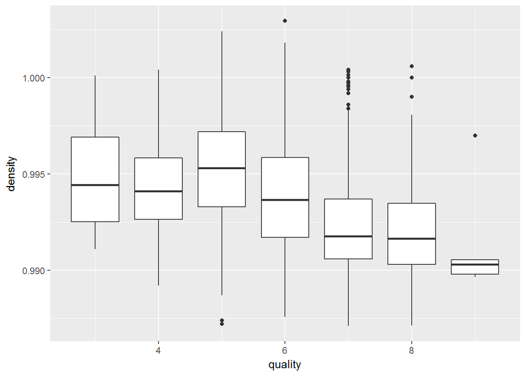

```
##
##  Pearson's product-moment correlation
##
## data:  wine$density and wine$quality
## t = -22.581, df = 4896, p-value < 2.2e-16
## alternative hypothesis: true correlation is not equal to 0
## 95 percent confidence interval:
##  -0.3322718 -0.2815385
## sample estimates:
##        cor
## -0.3071233
```

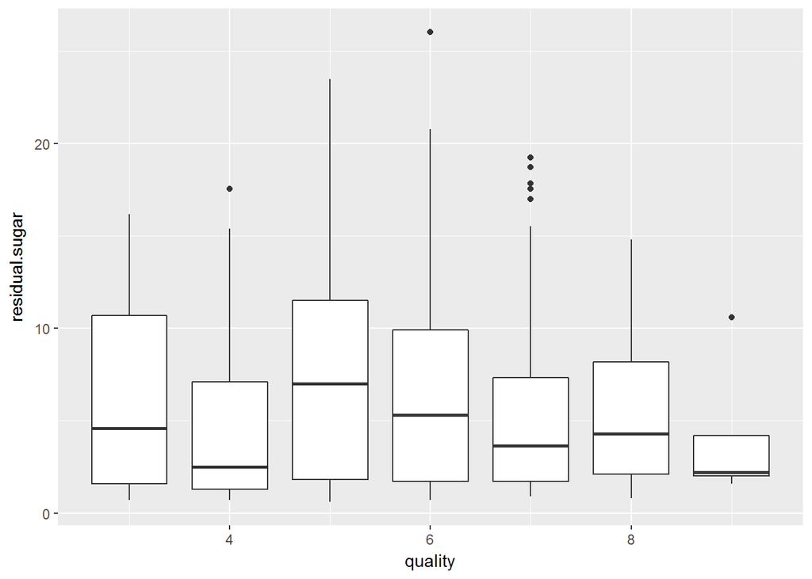

```
##
##  Pearson's product-moment correlation
##
## data:  wine$quality and wine$residual.sugar
## t = -6.8603, df = 4896, p-value = 7.724e-12
## alternative hypothesis: true correlation is not equal to 0
## 95 percent confidence interval:
##  -0.12524103 -0.06976101
## sample estimates:
##         cor
## -0.09757683
```

Indeed, residual.sugar and quality are negatively correlated, but only at -0.1. I would like to investigate sugar content more closely. Because there are so many wines that have a sugar content below 3, and sugar content is negatively correlated with quality, I’m going to analyze this subset of low-sugar wine.

```
##
##  Pearson's product-moment correlation
##
## data:  low_sugar_wine$residual.sugar and low_sugar_wine$quality
## t = 8.1326, df = 1866, p-value = 7.576e-16
## alternative hypothesis: true correlation is not equal to 0
## 95 percent confidence interval:
##  0.1408459 0.2284540
## sample estimates:
##       cor
## 0.1850175
```

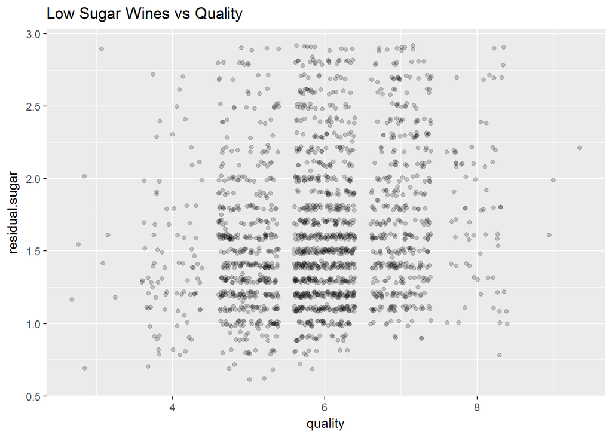

There is nothing super intesting to be found here. Although these low-sugar wines do correlate better with quality than the entire group, it is only a .18 corelation. I might look into this a bit deeper in the multivariate analysis section.

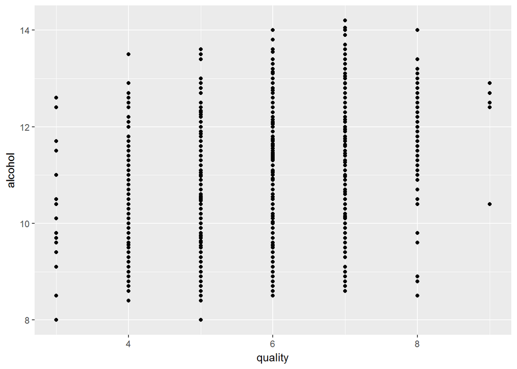

I am slightly concerned with the plot of wine quality vs alcohol content. We know they have a strong correlation, but it isn’t exactly easy to see in this chart.

```
##
##    3    4    5    6    7    8    9
##   20  163 1457 2198  880  175    5
```

```
##
##  Pearson's product-moment correlation
##
## data:  mediocre_wine$alcohol and mediocre_wine$quality
## t = 31.99, df = 4696, p-value < 2.2e-16
## alternative hypothesis: true correlation is not equal to 0
## 95 percent confidence interval:
##  0.3992279 0.4461944
## sample estimates:
##       cor
## 0.4229952
```

The correlation drops to .42 with this observations removed, but the correlation is still strong. Using the original data, I will modify the chart to show contrast between areas of higher concentration vs lower.

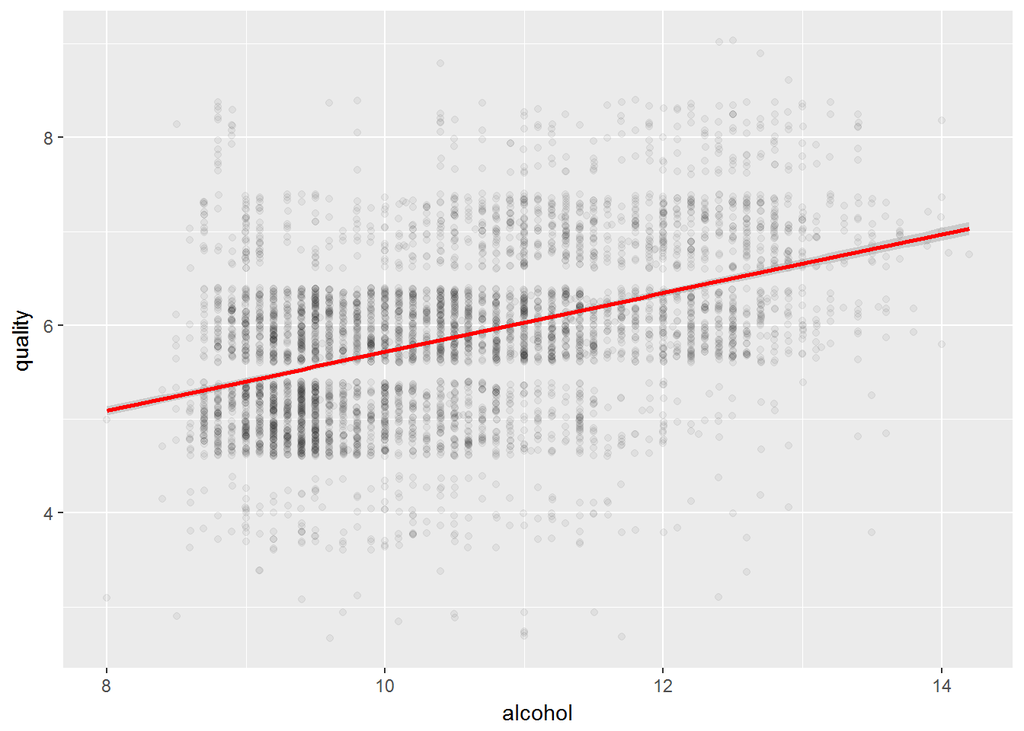

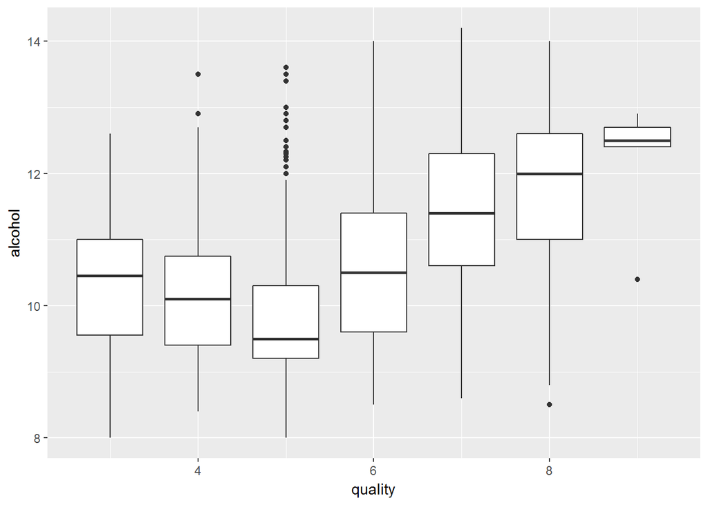

Here I can better the relationship between alcohol and quality. I would like to explore this relationship more in depth later.

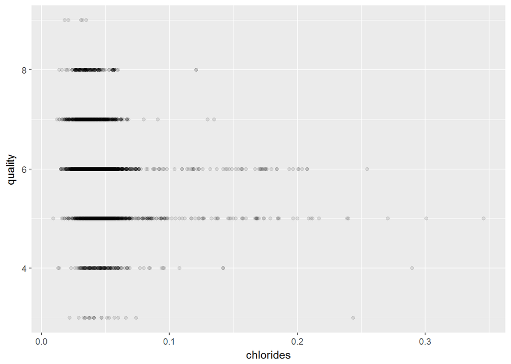

One thing I kept in mind was that correlation will not always tell you if there are relationships between variables going on. I looked through the charts to see if I could spot any patterns or clusters that might be missed by correlation alone. This chlorides/quality comparison is a good example. We can see that a lot of the bad wines have low chlorides, but the highly rated wines almost necessarily have relatively low chlorides as well. The mediocre wines have a mix of low chlorides to high chlorides.

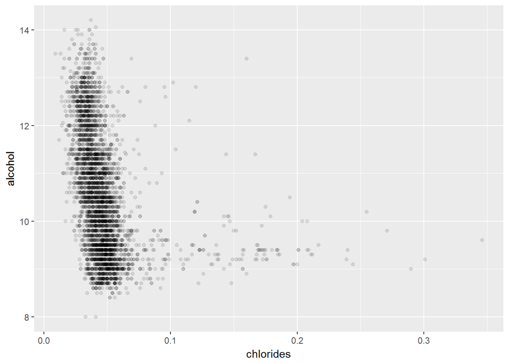

```
##
##  Pearson's product-moment correlation
##
## data:  wine$alcohol and wine$chlorides
## t = -27.016, df = 4896, p-value < 2.2e-16
## alternative hypothesis: true correlation is not equal to 0
## 95 percent confidence interval:
##  -0.3843183 -0.3355673
## sample estimates:
##        cor
## -0.3601887
```

There is a negative correlation between alcohol and chlorides, but there is also an interesting pattern we can see in the chart – wines with low chloride content have alcohol contents covering the entire specturm, but the higher cloride wines seem to have alcohol contents below 11%.

# Bivariate Analysis

### Talk about some of the relationships you observed in this part of the investigation. How did the feature(s) of interest vary with other features in the dataset?

There were many variables to be evaluated in this set of data. A large portion of the variables had insignificant correlation with each other and many would probably be considered useless on their own, regardless of correlation. As mentioned earlier, quality is the most important variable and I want to see how other variables affect it. Alcohol seems to be the most important, on the surface, but I will dig deeper into that later. Sugar and density remain variables of interest and might be studied further.

### Did you observe any interesting relationships between the other features (not the main feature(s) of interest)?

I did find a few standouts that had interesting cluster formations, such as alcohol’s relationship to chlorides and chlorides’ relationship to quality.

### What was the strongest relationship you found?

The strongest relationship was between sugar and desnity. While it is an interesting observation, I can’t say it is an important relationship.

# Multivariate Plots Section

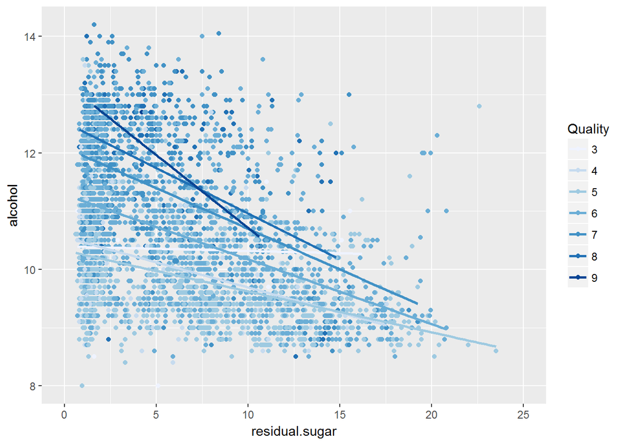

Here we can easily see the influence that alcohol and residual sugar have on quality.

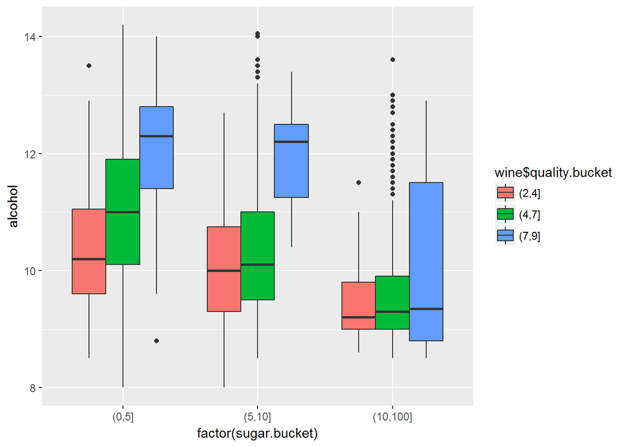

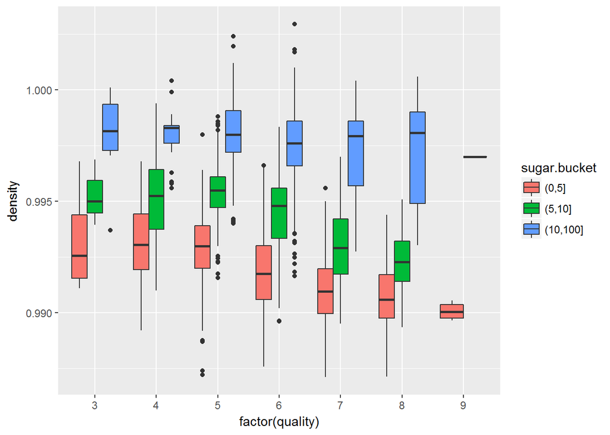

Here it is easy to the high correlation between sugar and density, and we can see the best wines tend to be less dense and less sugary.

```
##    Min. 1st Qu.  Median    Mean 3rd Qu.    Max.
##  0.9871  0.9917  0.9937  0.9940  0.9961  1.0390
```

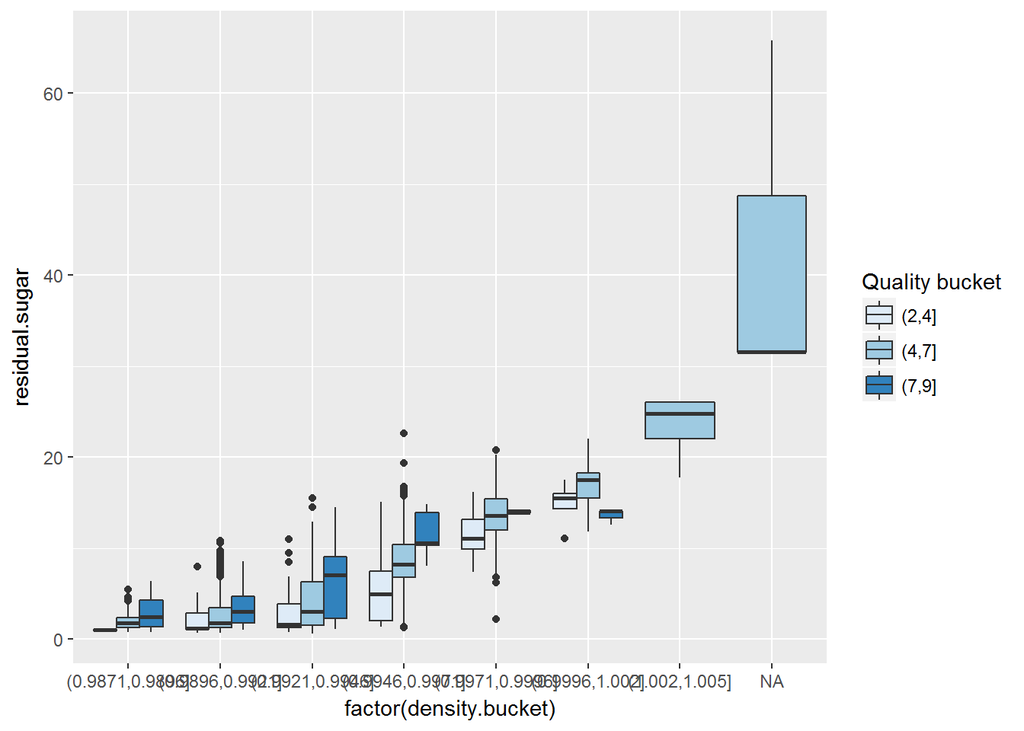

This chart may reveal one of the most interesting findings yet. Wines with relatively low sugar content for a given density tend to have a lower quality. Wines with a higher sugar content at a given density have a higher quality. This is especially interesting because, individually, they have negative correlations with quality.

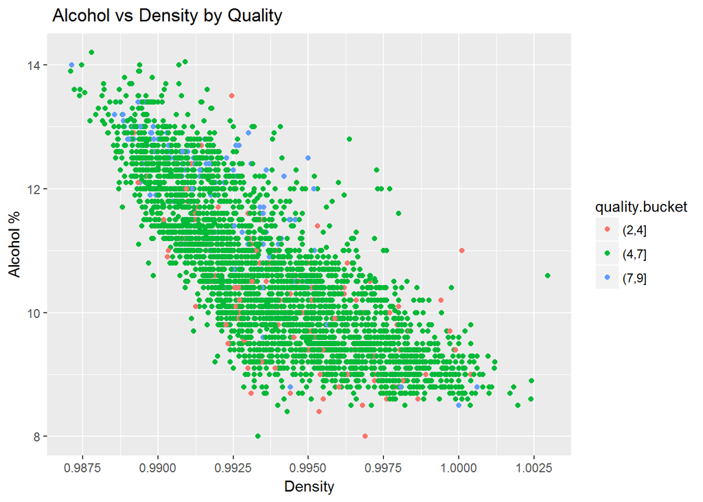